# Week 3 - R solutions

Snorre Jallbjørn

Autumn, 2021

# Exercise 1 - Fertility and population projections

## Question 1.1

- Mean age of mother increasing from current age to 40 in 2080; initial slope of 3 years per 30 years.
- Standard deviation of mother kept constant at current level.
- Total fertility increasing to a replacement level of 2.1 in 2080 with an initial slope of 0.005.

**Answer**: After running structure.r, we can use the `fertClass`.

```r
# Initialize the object
fert <- fertClass$new(DKfertdat)
```

```
## Imported historic data
##   - Age range  : 15 - 49
##   - Year range : 1973 - 2020
```

```r
# Define model specifications
initValue <- list(SDAgeMother   = tail(fert$histNormalPar$SDAgeMother,1))
initSlope <- list(MeanAgeMother = 3/30, BruttoFer = 0.005)
horiValue <- list(MeanAgeMother = 40  , BruttoFer = 2.1)
horizon   <- list(MeanAgeMother = 2080, BruttoFer = 2080)

# Estimate the model
fert$estimate(jumpoffValue = initValue
            , jumpoffSlope = initSlope
            , horizonValue = horiValue
            , horizon      = horizon)
```

```
## MeanAgeMother: Cubic spline starting at 31.43217 with slope 0.1 and ending in year 2080 at 40
## SDAgeMother  : Flat extrapolation at 4.729486
## BruttoFer    : Cubic spline starting at 1.6748 with slope 0.005 and ending in year 2080 at 2.1
```

The estimates can be extracted using the `plotdatEstimates`-method

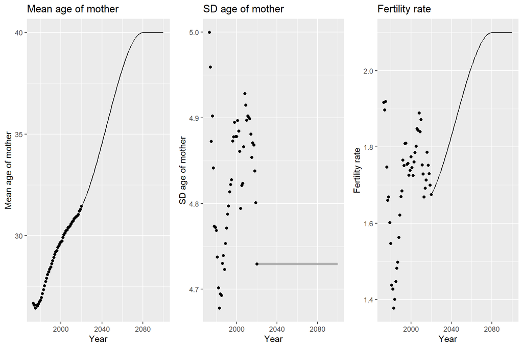

```r
# Extract estimates
plotdat <- fert$plotdatEstimates(horizon = 2100-2020)

# Plot
library("ggplot2")
library("gridExtra")

p1 <- ggplot(data = plotdat) +
  geom_point(aes(x = Year, y = HistMeanAgeMother)) +
  geom_line(aes(x = Year, y = ProjMeanAgeMother)) +
  labs(title = "Mean age of mother",
       y     = "Mean age of mother")

p2 <- ggplot(data = plotdat) +
  geom_point(aes(x = Year, y = HistSDAgeMother)) +
  geom_line(aes(x = Year, y = ProjSDAgeMother)) +
  labs(title = "SD age of mother",
       y     = "SD age of mother")

p3 <- ggplot(data = plotdat) +
  geom_point(aes(x = Year, y = HistBruttoFer)) +
  geom_line(aes(x = Year, y = ProjBruttoFer)) +
  labs(title = "Fertility rate",
       y     = "Fertility rate")

grid.arrange(p1, p2, p3, ncol = 3)
```

## Question 1.2

**Answer**:

```r
OEdata <- HMDobj$getOEdata(agelim = c(0,100), timelim = c(1995, 2020))
mort   <- mortClass$new(OEdata)
```

```
## ----------------- Estimating Lee-Carter model -----------------
##
##  -  Ages: 0 - 100
##  - Years: 1995 - 2020
##
##  - Estimating parameters for group 'Female' ....
##    > Estimation converged after 17 iterations.
##
##  - Estimating parameters for group 'Male' ....
##    > Estimation converged after 18 iterations.
##
## --------------------- Estimation complete ---------------------
```

```r
mortdat <- mort$getMu(timelim = c(1995, 2250))
fertdat <- fert$getFer(timelim = c(1995, 2250))

pop <- popClass$new("Data/DNK_Pop_1x1.txt")
```

```
## Imported historic data for Denmark
##   - Groups     : 2
##   - Age range  : 0 - 100
##   - Year range : 1835 - 2021
```

```r
pop$setMortAndFert(mortdat, fertdat)

plotdat <- pop$plotdat(agelim = c(15, 100), timelim = c(1900, 2250))
```

```
## Two-group mode: Fertility will be applied to group Female only (one-sex fertility).
##                 Births are distributed with 0.487 to Female and 0.513 to Male
```

```r
library("dplyr")

# Aggregate data...
plotdat$working <- (plotdat$Age<=65)
plotdat <- plotdat %>% group_by(Year) %>% summarise(Ratio = sum(N[!working])/sum(N[working]))
str(plotdat)
```

```
## tibble [351 x 2] (S3: tbl_df/tbl/data.frame)
##  $ Year : int [1:351] 1900 1901 1902 1903 1904 1905 1906 1907 1908 1909 ...
##  $ Ratio: num [1:351] 0.102 0.101 0.101 0.102 0.102 ...
```

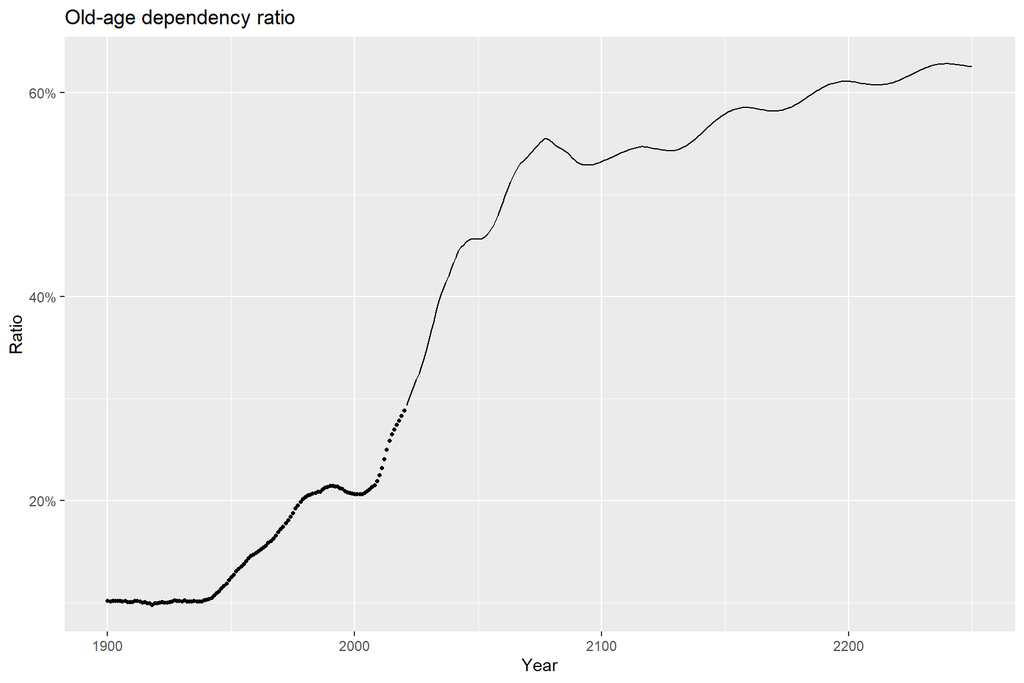

```r
plotdat$histRatio <- ifelse(plotdat$Year <= 2020, plotdat$Ratio, NA)
plotdat$projRatio <- ifelse(plotdat$Year  > 2020, plotdat$Ratio, NA)

# ... and plot
ggplot(plotdat, aes(x = Year)) +
  geom_point(aes(y = histRatio), size = 0.9) +
  geom_line(aes(y = projRatio)) +
  labs(title = 'Old-age dependency ratio', y = 'Ratio') +
  scale_y_continuous(labels = scales::percent_format())
```

# Exercise 3

## Question 3.1

**Question**: Plot the age composition of the Danish population in 2020.

**Answer**:

```r
pop <- popClass$new("Data/DNK_Pop_1x1.txt")
```

```
## Imported historic data for Denmark
##   - Groups     : 2
##   - Age range  : 0 - 100
##   - Year range : 1835 - 2021
```

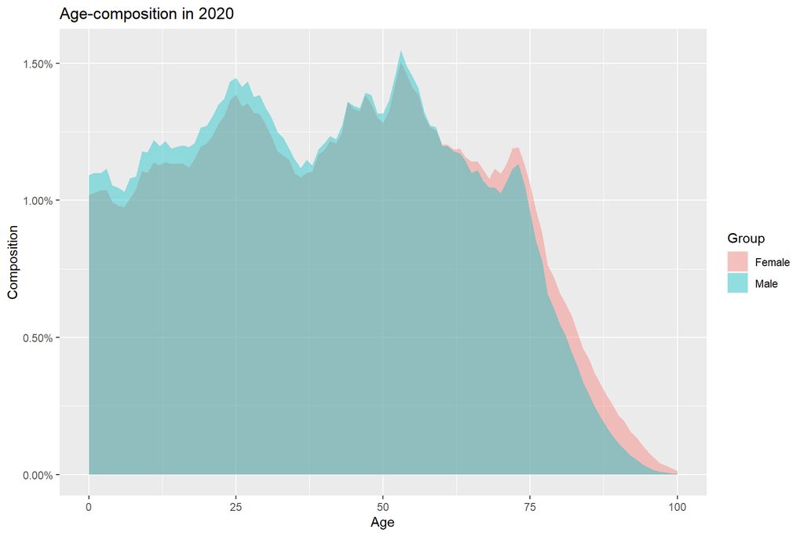

```r
plotdat <- pop$plotdat(timelim = 2020)[,c("Group", "Age", "Year", "c")]

ggplot(plotdat, aes(x = Age, y = c, fill = Group)) +
  geom_area(position = "identity", alpha = .4) +
  labs(title = "Age-composition in 2020", y = "Composition") +
  scale_y_continuous(labels = scales::percent_format())
```

## Question 3.2

**Answer**: Projection of the population under stable rates:

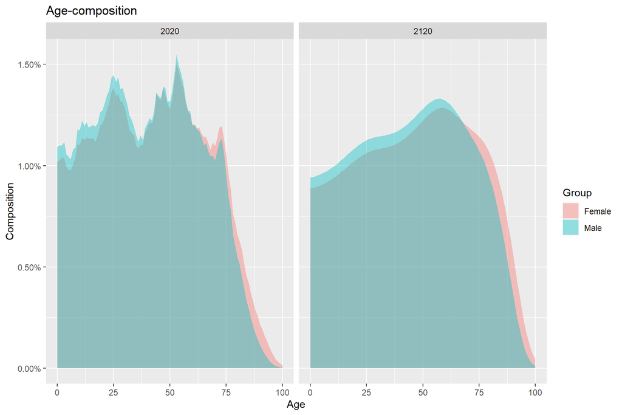

```r
library("dplyr")
library("reshape2")

# Historic data
mu2020 <- drop(HMDobj$getSmoothMu(agelim = c(0,100), timelim = 2020)$mu)
fe2020 <- drop(fert$getFer(timelim = 2020)$fer)
N2020  <- pop$getPop(agelim = c(0,100), timelim = 2020)
Smat   <- apply(mu2020, 1, function(x) c(1, exp(-cumsum(x[-length(x)]))))

endYr  <- 2120

projectPop <- function(horizon, mortMat, fertvec, initpop, propfemale = 0.487) {
    agevec      <- lim2vec(initpop$agelim)           # Ages
    lastage     <- ncol(mortMat)                     # Last age always dies...
    b.prop      <- c(propfemale, 1-propfemale)       # Proportion of female vs male births
    fertileAges <- agevec %in% (1:length(fertvec)-1) # Pick out the ages giving birth

    # Initialize N: Array w. dim. Group x Age x Year
    N <- array(NA, dim = c(2L, lim2length(initpop$agelim), horizon),
               dimnames = list("Group" = c("Female", "Male"),
                               "Age"   = lim2vec(initpop$agelim),
                               "Year"  = initpop$timelim[1L]+1L:horizon))
    N[,,1L] <- initpop$N
    for (t in seq_len(horizon-1L)) {
        # Pop. at time t
        primoN <- N[,,t]

        # Who die and survive ?
        dead      <- primoN*(1-exp(-mortMat))
        survivors <- primoN - dead

        # Births among survivors and dead
        # The dead die on 1 July, so only fertile for 6 months
        # We implicitly assume that all babies are born at exactly time t+1
        b.surv <- b.prop*sum(survivors[1,fertileAges]*fertvec)
        b.dead <- b.prop*sum(dead[1,fertileAges]*(fertvec/2))
        births <- b.surv + b.dead

        # Update N - Pop. at time t+1
        N[,,t+1L] <- cbind(births, survivors[,-lastage])
    }

    # Return data.frame for plotting
    ret <- as.data.frame(melt(N, c("Group", "Age", "Year"), value.name = "N") %>%
                             group_by(Group, Year) %>% mutate("c" = N/sum(N)))
}

Nproj <- projectPop(endYr-2020, mu2020, fe2020, N2020)

plotdat.wproj <- rbind(plotdat, Nproj[Nproj$Year==endYr, -4])

pAgeComp <- ggplot(plotdat.wproj, aes(x = Age, y = c, fill = Group)) +
  geom_area(position = "identity", alpha = .4) +
  labs(title = "Age-composition", y = "Composition") +
  scale_y_continuous(labels = scales::percent_format()) + facet_grid(~Year)
pAgeComp
```

## Question 3.3

**Question**: Compute the intrinsic growth rate $r$ by finding the solution to the equation
$$1 = \int_0^\infty e^{-rx} S(x) F(x) \text{d}x,$$
where $S$ is the survival function and $F$ is the rate of bearing female children, in each of the two cases above. Superimpose the stable equivalent population on the two plots from the previous question.

To compute the intrinsic growth rate, we solve the integral equation.

```r
calc.intrinsic.growth <- function(mortvec, fertvec, propfemale = 0.487) {
    stopifnot(length(fertvec) <= length(mortvec))
    agevec  <- 1:length(fertvec)
    survvec <- c(1, exp(-cumsum(mortvec)))
    w       <- survvec[agevec]*fertvec*propfemale
    uniroot(function(r) {1-sum(exp(-r*agevec)*w)}, interval = c(-0.02, 0.02), tol = 1e-8)$root
}

r.f <- calc.intrinsic.growth(mu2020["Female",], fe2020)
r.m <- calc.intrinsic.growth(mu2020["Male",]  , fe2020)
round(c(r.f, r.m)*100,4)
```

```
## [1] -0.6482 -0.6632
```

The age distribution in the stable population is given by (Preston et al. (7.9) p. 145)
$$c(x)=\frac{e^{-rx}S(x)}{\int_0^\infty e^{-rx}S(x) \text{d}x},$$
where $S(x)$ is the survival function.

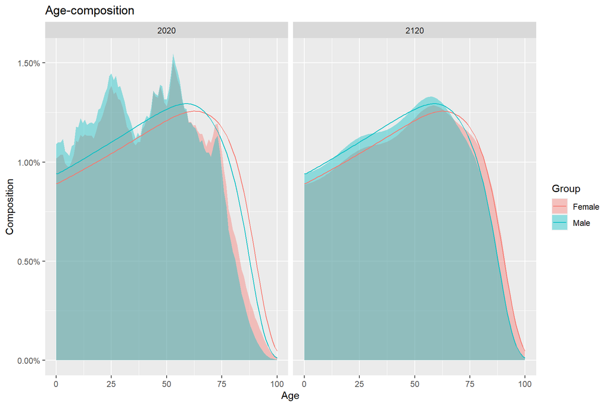

```r
xvec <- lim2vec(N2020$agelim)

c.stable.f <- Smat[,1]*exp(-r.f*xvec)/sum(Smat[,1]*exp(-r.f*xvec))
c.stable.m <- Smat[,2]*exp(-r.m*xvec)/sum(Smat[,2]*exp(-r.m*xvec))

plotdat.stable <- data.frame("Group" = rep(c("Female", "Male"), each = length(xvec)),
                             "Age"   = rep(xvec, times = 2),
                             "c"     = c(c.stable.f, c.stable.m))

pAgeComp + geom_line(data = plotdat.stable, aes(x = Age, y = c, color = Group))
```

## Question 3.4

**Question**: What happens to the intrinsic growth rate, and, by extension, the stable equivalent population if all age-specific fertility rates are increased by, say, 40%?

```r
delta.high <- 1.4

Nproj.high <- projectPop(endYr-2020, mu2020, fe2020*delta.high, N2020)

plotdat.wprojhigh <- rbind(plotdat, Nproj.high[Nproj.high$Year==endYr, -4])

r.f.high <- calc.intrinsic.growth(mu2020["Female",], fe2020*delta.high)
r.m.high <- calc.intrinsic.growth(mu2020["Male",]  , fe2020*delta.high)
round(c(r.f.high, r.m.high)*100,4)
```

```
## [1] 0.3886 0.3737
```

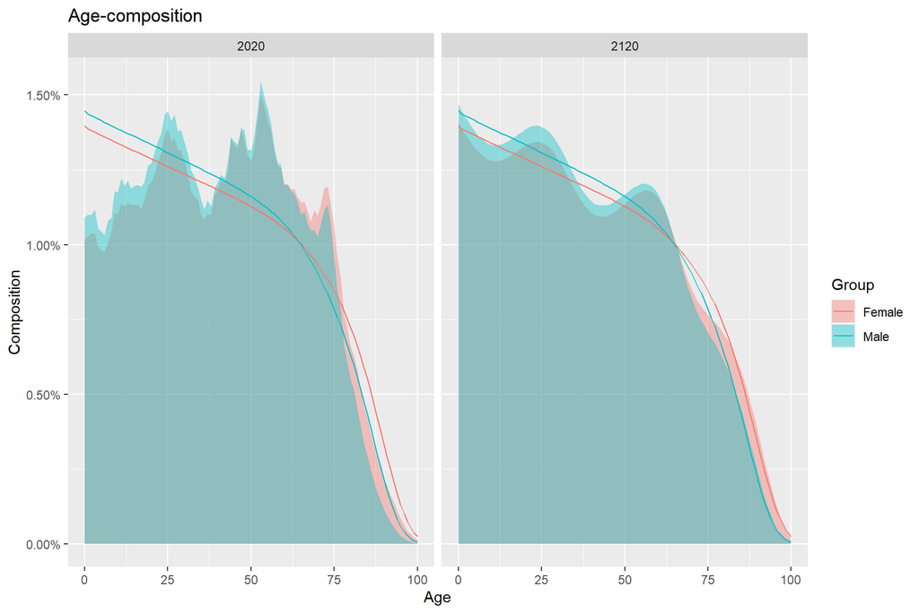

```r
c.stable.f <- Smat[,1]*exp(-r.f.high*xvec)/sum(Smat[,1]*exp(-r.f.high*xvec))
c.stable.m <- Smat[,2]*exp(-r.m.high*xvec)/sum(Smat[,2]*exp(-r.m.high*xvec))

plotdat.stable <- data.frame("Group" = rep(c("Female", "Male"), each = length(xvec)),
                             "Age"   = rep(xvec, times = 2),
                             "c"     = c(c.stable.f, c.stable.m))

ggplot(plotdat.wprojhigh, aes(x = Age, y = c, fill = Group)) +
  geom_area(position = "identity", alpha = .4) +
  geom_line(data = plotdat.stable, aes(x = Age, y = c, color = Group)) +
  labs(title = "Age-composition", y = "Composition") +
  scale_y_continuous(labels = scales::percent_format()) + facet_grid(~Year)
```

# Exercise 4 (BONUS): Population momentum

In a stable population, we have
$$N(t) = B(t) e_r(0),$$
where $B(t) = Ce^{rt}$ is the birth process and $e_r(0) = \int_0^\infty e^{-rx}S(x) \ \text{d}x$ the average life span. The constant $C$ can be expressed as
$$C = \frac{G_0}{A_0}$$
with
$$G_0 = \int_0^\infty e^{-rt} G(t) \ \text{d}t = \int_0^\infty e^{-rt} \int_0^\infty N(x,0) \frac{S(t+x)}{S(t)}F(t+x) \ \text{d}x \ \text{d}t,$$
the mean number of children born for women alive at time zero, and
$$A_0 = \int_0^\infty e^{-rx} xS(x)F(x) \ \text{d}x,$$
the mean age of childbearing.

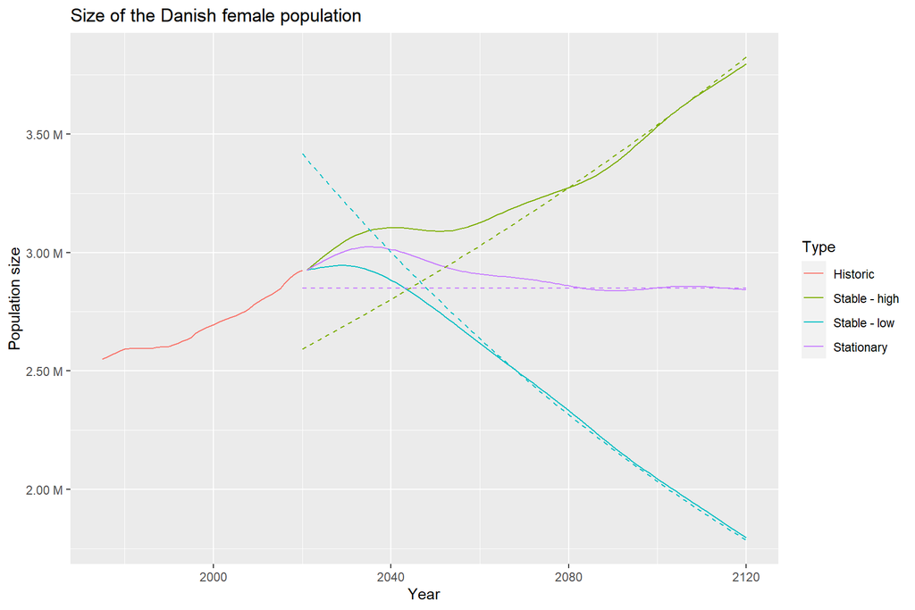

```r
library("dplyr")
plotdat <- pop$plotdat(groups = "Female", timelim = c(1975, 2020))
plotdat <- plotdat %>% group_by(Year) %>% summarize(N = sum(N))

delta.stat.f <- uniroot(function(delta) {1-sum(Smat[1:length(fe2020),1]*fe2020*0.487*delta)},
                        interval = c(-2, 2), tol = 1e-8)$root
Nproj.stat   <- projectPop(endYr-2020, mu2020, fe2020*delta.stat.f, N2020)

Nhist        <- pop$plotdat(groups = "Female", timelim = c(1975, 2020)) %>% select(c("Age", "Year", "N"))
Nproj.f      <- Nproj[Nproj$Group == "Female", c("Age", "Year", "N")]
Nproj.high.f <- Nproj.high[Nproj.high$Group == "Female", c("Age", "Year", "N")]
Nproj.stat.f <- Nproj.stat[Nproj.stat$Group == "Female", c("Age", "Year", "N")]

plotdat <- rbind(cbind(Nhist       , "label" = "Historic"),
                 cbind(Nproj.f     , "label" = "Stable - low"),
                 cbind(Nproj.high.f, "label" = "Stable - high"),
                 cbind(Nproj.stat.f, "label" = "Stationary"))

plotdat <- plotdat %>% group_by(Year, label) %>% summarize(N=sum(N))

calc.A0 <- function(survvec, fertvec, grpprop, r) {
    stopifnot(length(fertvec) <= length(survvec))
    agevec  <- 1:length(fertvec)
    sum(agevec*exp(-r*agevec)*survvec[agevec]*fertvec*grpprop)
}

calc.G0 <- function(Nvec, survvec, fertvec, grpprop, r) {
    stopifnot(length(fertvec) <= length(survvec))
    n_a    <- length(fertvec)
    agevec <- 1:n_a

    Nvec   <- Nvec[agevec]
    Svec   <- survvec[agevec]
    Fvec   <- fertvec*grpprop

    w <- rep(0, n_a)
    for (x in agevec) {
        idx  <- x:n_a
        w[x] <- sum(Nvec[1:length(idx)]*Svec[idx]*Fvec[idx])
    }
    sum(exp(-r*agevec)*w/Svec)
}

calc.e0r <- function(survvec, r) {
    agevec <- 1:length(survvec)-1
    sum(exp(-r*agevec)*survvec)
}

calc.asymp.stable.pop <- function(Nvec, mortvec, fertvec, grpprop, r, horizon, startYr = 2020) {
    survvec <- c(1,exp(-cumsum(mortvec[-length(mortvec)])))
    G0  <- calc.G0(Nvec, survvec, fertvec, grpprop, r)
    A0  <- calc.A0(survvec, fertvec, grpprop, r)
    e0r <- calc.e0r(survvec,r)
    data.frame("Year" = startYr + 0:horizon,"N" = G0/A0*exp(r*(0:horizon))*e0r)
}

Nvec    <- Nhist[Nhist$Year == 2020, "N"]

asymp_low        <- calc.asymp.stable.pop(Nvec,mu2020[1,],fe2020             ,0.487,r.f     , endYr-2020)
asymp_high       <- calc.asymp.stable.pop(Nvec,mu2020[1,],fe2020*delta.high  ,0.487,r.f.high, endYr-2020)
asymp_stat       <- calc.asymp.stable.pop(Nvec,mu2020[1,],fe2020*delta.stat.f,0.487,0       , endYr-2020)
asymp_low$label  <- "Stable - low"
asymp_high$label <- "Stable - high"
asymp_stat$label <- "Stationary"

plotdat_asymp <- rbind(asymp_low, asymp_high, asymp_stat)


ggplot(mapping = aes(x = Year, y = N, color = label)) +
  geom_line(data = plotdat) +
  geom_line(data = plotdat_asymp, linetype = "dashed") +
  scale_y_continuous(labels = scales::unit_format(unit = "M", scale = 1e-6)) +
  labs(title = 'Size of the Danish female population', y = 'Population size', color = 'Type')
```